# Gene Structure Tools: Analysis and Manipulation of Spliced Gene Structures

Beth Signal

30 December 2017 / Version 0.5.0

[figure not shown]

## Introduction

GeneStructureTools is an in-development package for the manipulation and analysis of transcribed gene structures.

We have provided functions for importing Whippet alternative splicing data, and the analysis of these splicing events. Splicing events can also be defined manually if you are using a different splicing analysis tool to Whippet. For specific events - currently including exon skipping, intron retention, alternative splice site usage and alternative first/last exons - transcripts can be made in silico which use the two splicing modes - i.e. transcripts containing and transcripts skipping an exon. These transcripts do not have to be pre-annotated, and thus all potential isoforms can be compared for an event.

Current comparisons of transcripts include annotating and analysing ORF and UTR features (length, locations, difference/similarity between transcripts), and predicting nonsense mediated decay (NMD) potential.

We also have functions for re-annotation of .GTF features, such as annotating UTRs as 3’ or 5’, and assigning a broader biotype for genes and transcripts so more informative analysis can be performed between these classes.

## Importing Differential Splicing Data

Currently, very few available tools output splicing event type information (i.e. exon skipping, intron retention) within tested genes. GeneStructureTools currently has functions for importing data from:

[**whippet**](https://github.com/timbitz/Whippet.jl)

[**DEXSeq**](http://bioconductor.org/packages/release/bioc/html/DEXSeq.html)

### Whippet

**0. Data Preparation**

You will also need to download the Gencode GTF file from [here](http://www.gencodegenes.org/mouse_releases/14.html).

**1. Read in Whippet files**

```r
# Load packages
library(GeneStructureTools)
library(GenomicRanges)
library(stringr)
library(BSgenome)

# list of files in the whippet directory
whippet_files <- list.files("~/Downloads/GeneStructureTools_VignetteFiles/",full.names = TRUE)

# read in junction files (junctions + read counts)
whippet_jnc <- readWhippetJNCfiles(grep(".jnc", whippet_files,value = TRUE))
jnc_ranges <- formatJunctions(whippet_jnc)

# read in psi (percent spliced in) files (default: total reads for each event)
whippet_counts <- readWhippetPSIfiles(grep(".psi", whippet_files,value = TRUE))

# read in diff files (events + differential splicing testing)
whippet_diff <- readWhippetDIFFfiles(grep(".diff", whippet_files,value = TRUE))

# format events as a GRanges Object
whippet_coords <- formatWhippetEvents(whippet_diff)

# create a sample table with sample id, condition and replicate
whippet_sampleTable <- data.frame(sample=c("A01","B01","A21","B21"),
                                  condition=c("01","01","21","21"),
                                  replicate=(c("A","B","A","B")))

# You may need to manually annotate conditions in the differential splicing data.frame to match the condition column in whippet_sampleTable

conditions <- whippet_diff$comparison
whippet_diff$condition_1 <- unlist(lapply(str_split(conditions,"_v_"),"[[",1))
whippet_diff$condition_2 <- unlist(lapply(str_split(conditions,"_v_"),"[[",2))

# read in gtf annotation
gtf <- rtracklayer::import("~/Downloads/gencode.vM14.annotation.gtf.gz")
gtf.exons <- gtf[gtf$type=="exon"]
gtf.transcripts <- gtf[gtf$type=="transcript"]

# add first/last annotation (speeds up later steps)
if(!("first_last" %in% colnames(mcols(gtf.exons)))){
    t <- as.data.frame(table(gtf.exons$transcript_id))
    gtf.exons$first_last <- NA
    gtf.exons$first_last[gtf.exons$exon_number == 1] <- "first"
    gtf.exons$first_last[gtf.exons$exon_number == t$Freq[match(gtf.exons$transcript_id, t$Var1)]] <- "last"
}

# specify the BSGenome annotation
g <- BSgenome.Mmusculus.UCSC.mm10::BSgenome.Mmusculus.UCSC.mm10

save.image("~/Downloads/GeneStructureTools_VignetteFiles/mouse.Rdata")
```

**2. Summarise changes in gene structures due to splicing**

```r
# filter events for significance
significant_events <- filterSignificantWhippetEvents(whippet_diff,
                                                     probability = 0.95, # min probability
                                                     psiDelta = 0.1, # min change in PSI
                                                     eventTypes = "all", # all event types
                                                     whippetCounts = whippet_counts,
                                                     minCounts = 100, # mean of at least 100 counts in one condition
                                                     sampleTable = whippet_sampleTable)

# check for changes in gene/transcript structure
summary <- whippetTranscriptChangeSummary(significantEvents = significant_events,
                                           whippetCoords = whippet_coords,
                                           gtf.exons = gtf.exons,
                                           gtf.transcripts = gtf.transcripts,
                                           BSgenome = g,
                                           jncCoords = jnc_ranges,
                                           NMD = FALSE # ignore nonsense mediated decay (for now)
                                           )
head(summary)
```

```
##                       gene node                  coord strand type
## 1097 ENSMUSG00000014602.15   41 chr1:93034546-93034572      -   CE
## 2356 ENSMUSG00000032883.15    3 chr1:78663141-78663280      +   CE
## 2552 ENSMUSG00000026131.18  116 chr1:34296742-34296759      +   CE
## 2828 ENSMUSG00000037470.14   27 chr1:36176776-36176799      -   CE
## 3332 ENSMUSG00000048234.13    5 chr1:39558315-39558411      -   CE
## 4272 ENSMUSG00000018417.14   31 chr1:51768650-51768736      -   CE
##         psi_a   psi_b psi_delta probability complexity entropy
## 1097 0.043739 0.16040  -0.11666       0.987         K2  0.6593
## 2356 0.353040 0.13494   0.21810       1.000         K1  0.9619
## 2552 0.338650 0.52667  -0.18802       0.994         K3  1.5679
## 2828 0.660880 0.82492  -0.16404       0.956         K1  0.9645
## 3332 0.707580 0.90124  -0.19367       0.996         K1  0.9183
## 4272 0.596080 0.24059   0.35549       1.000         K2  1.2408
##                                              unique_name comparison
```

[output cut: 69 more lines]

## Altering Gene and Transcript Structures

whippetTranscriptChangeSummary() combines several functions for analysing changes in gene structures. While this has been made to simplify analysis from whippet data, individual functions can be used on other data sources or manually annotated gene structures. It may also be helpfule to run each individual step if you would like to manually investigate changes to genes.

### Exon skipping

Exon skipping, or cassette exon usage, occurs when a single exon is spliced out of the mature transcript.

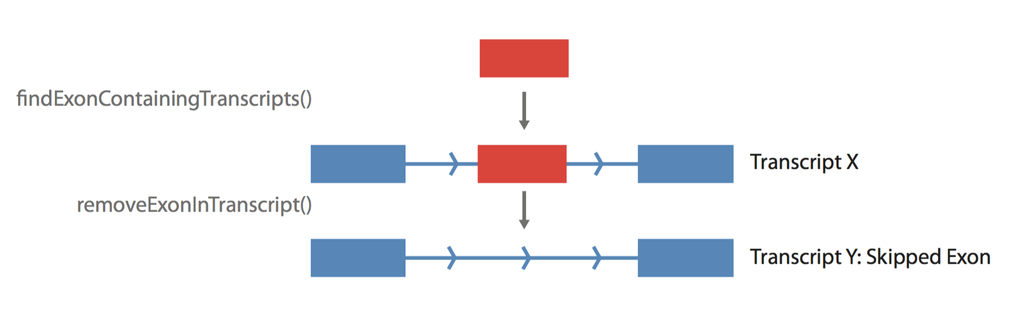

Removal of a skipped exon

**1.a. Find skipped exon events**

```r
# filter out skipped exon events (coded as "CE")
significant_events.ce <- significant_events[significant_events$type=="CE",]

# we will be looking at Ndufv3 (ENSMUSG00000024038.16)
significant_events.ce <- significant_events.ce[significant_events.ce$gene == "ENSMUSG00000024038.16",]
# psi_a = 0.137, psi_b = 0.275
# percentage of transcripts skipping exon 3 decreases from timepoint 1 to 21

# whippet outputs the skipped exon coordinates
ranges.ce <- whippet_coords[whippet_coords$id %in% significant_events.ce$coord]
ranges.ce
```

```
## GRanges object with 1 range and 1 metadata column:
##       seqnames               ranges strand |                      id
##          <Rle>            <IRanges>  <Rle> |             <character>
##   [1]    chr17 [31527310, 31528401]      + | chr17:31527310-31528401
##   -------
##   seqinfo: 21 sequences from an unspecified genome; no seqlengths
```

*or*

**1.b. Create skipped exon events**

```r
ranges.ce.manual <- GRanges(seqnames="chr17",
                            ranges=IRanges(start=31527310, end=31528401),
                            strand="+",
                            id="Ndufv3_manual")

# or from an annotated exon
ranges.ce.gtf <- gtf.exons[gtf.exons$exon_id == "ENSMUSE00000315216.3"]
ranges.ce.gtf$id <- "Ndufv3_manual"
```

**2. Find transcripts which overlap the skipped exon, and create normal & skipped exon isoforms**

```r
# find exons in the gtf that overlap the skipped exon event
exons.ce <- findExonContainingTranscripts(eventCoords = ranges.ce,
                                          gtf.exons = gtf.exons,
                                          gtf.transcripts = gtf.transcripts)
# make skipped and included exon transcripts
# removes the skipped exon from all transcripts which contain it
skippedExonTranscripts <- skipExonInTranscript(eventCoords = ranges.ce,
                                               skippedExons = exons.ce,
                                               gtf.exons,
                                               match="exact")
```

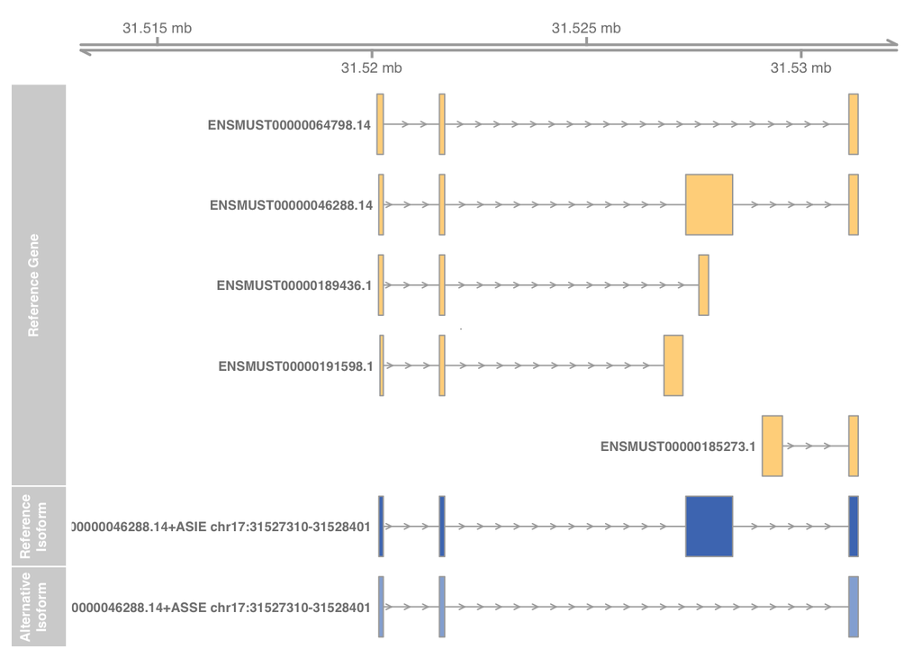

```r
## make Gvis models
# set up for visualisation
library(Gviz)
gtr <- Gviz::GenomeAxisTrack()

# all transcripts for the gene
geneModel.all <- GeneRegionTrack(makeGeneModel(gtf.exons[gtf.exons$gene_id == skippedExonTranscripts$gene_id[1]]),
                                 name="Reference Gene",
                                 showId=TRUE,transcriptAnnotation = "transcript")
# reference transcript
geneModelNormal <- GeneRegionTrack(makeGeneModel(skippedExonTranscripts[skippedExonTranscripts$set=="included_exon"]),
                                   name="Reference Isoform",
                                   showId=TRUE, fill="#4D7ABE",transcriptAnnotation = "transcript")
# for the skipped exon transcript
geneModelSkipped <- GeneRegionTrack(makeGeneModel(skippedExonTranscripts[skippedExonTranscripts$set=="skipped_exon"]),
                                   name="Alternative Isoform",
                                   showId=TRUE, fill="#94AFD8",transcriptAnnotation = "transcript")

plotTracks(list(gtr,geneModel.all,geneModelNormal, geneModelSkipped), extend.left = 1000, extend.right = 1000)
```

```r
# Only the transcript isoform containing the skipped exon (exon 3) is used for analysis, and a 'novel' isoform is created by exon skipping
```

### Intron Retention

Intron Retention occurs when an intron is not spliced out of the mature transcript.

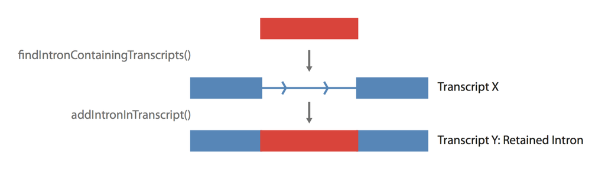

Addition of a retained intron

**1. Create normal and retained isoform structures from whippet coordinates**

```r
# filter out retained events (coded as "RI")
significant_events.ri <- significant_events[significant_events$type=="RI",]

# we will be looking at Srsf1 (ENSMUSG00000018379.17)
significant_events.ri <- significant_events.ri[significant_events.ri$gene == "ENSMUSG00000018379.17",]

# whippet outputs the retained coordinates
ranges.ri <- whippet_coords[whippet_coords$id %in% significant_events.ri$coord]
# need to extend whippet coords to cover the last/first base of the surrounding exons
start(ranges.ri) <- start(ranges.ri) -1
end(ranges.ri) <- end(ranges.ri) +1
ranges.ri
```

```
## GRanges object with 1 range and 1 metadata column:
##       seqnames               ranges strand |                      id
##          <Rle>            <IRanges>  <Rle> |             <character>
##   [1]    chr11 [88049215, 88049412]      + | chr11:88049216-88049411
##   -------
##   seqinfo: 21 sequences from an unspecified genome; no seqlengths
```

```r
# manually create
ranges.ri.manual <- GRanges(seqnames="chr11",
                            ranges=IRanges(start=88049215, end=88049412),
                            strand="+",
                            id="Srsf1_manual")
```

**2. Find transcripts which overlap the intron, and create normal & retained intron isoforms**

```r
# find exons pairs in the gtf that bound the retained intron event
exons.ri <- findIntronContainingTranscripts(eventCoords = ranges.ri,
                                            gtf.exons)

# make retained and non-retained transcripts
# adds the intron into all transcripts which overlap it
retainedIntronTranscripts <- addIntronInTranscript(eventCoords = ranges.ri,
                                                   flankingExons = exons.ri,
                                                   gtf.exons,
                                                   glueExons = TRUE)
```

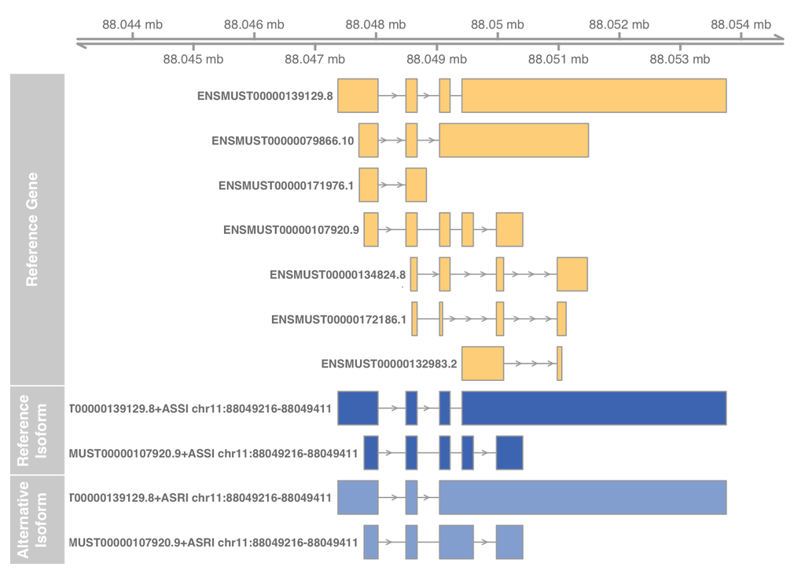

```r
## make Gviz models
# all transcripts for the gene
geneModel.all <- GeneRegionTrack(makeGeneModel(gtf.exons[gtf.exons$gene_id == retainedIntronTranscripts$gene_id[1]]),
                                 name="Reference Gene",
                                 showId=TRUE,transcriptAnnotation = "transcript")
# reference transcript
geneModelNormal <- GeneRegionTrack(makeGeneModel(retainedIntronTranscripts[retainedIntronTranscripts$set=="spliced_intron"]),
                                   name="Reference Isoform",
                                   showId=TRUE, fill="#4D7ABE",transcriptAnnotation = "transcript")
# for the retained intron transcript
geneModelRetained <- GeneRegionTrack(makeGeneModel(retainedIntronTranscripts[retainedIntronTranscripts$set=="retained_intron"]),
                                   name="Alternative Isoform",
                                   showId=TRUE, fill="#94AFD8",transcriptAnnotation = "transcript")

# Only the transcript isoforms with exons at the boundries of the retained intron are used for analysis, and 'novel' isoforms are created by intron retention
plotTracks(list(gtr,geneModel.all,geneModelNormal, geneModelRetained), extend.left = 1000, extend.right = 1000)
```

### Alternative acceptor and donor splice sites

Creation of alternative donor/acceptor isoforms currently relies on junction read counts supplied by whippet.

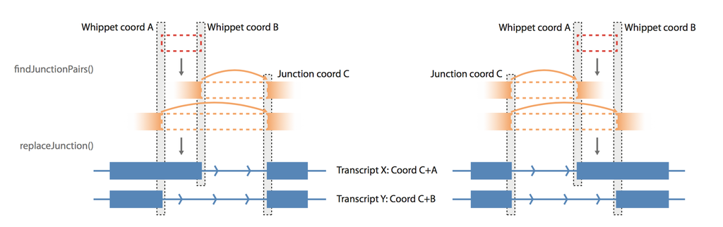

Creation of transcripts with an alternative donor (left) or acceptor (right) splice site.

#### Aternative acceptor

**1. Create normal and alternative isoform structures from whippet coordinates**

```r
# filter out alternative acceptor events (coded as "AA")
significant_events.aa <- significant_events[significant_events$type=="AA",]

# we will be looking at Poglut1 (ENSMUSG00000034064.14)
significant_events.aa <- significant_events.aa[significant_events.aa$gene == "ENSMUSG00000034064.14",]

# whippet outputs the retained coordinates
ranges.aa <- whippet_coords[whippet_coords$id %in% significant_events.aa$coord]
# AA/AD coordinates range from the normal acceptor splice site to the alternative acceptor splice site
ranges.aa
```

```
## GRanges object with 1 range and 1 metadata column:
##       seqnames               ranges strand |                      id
##          <Rle>            <IRanges>  <Rle> |             <character>
##   [1]    chr16 [38549434, 38549636]      - | chr16:38549434-38549636
##   -------
##   seqinfo: 21 sequences from an unspecified genome; no seqlengths
```

```r
# find exons pairs in the gtf that bound the retained intron event
junctionPairs <- findJunctionPairs(eventCoords = ranges.aa,
                                   jncCoords = jnc_ranges,
                                   type="AA")
junctionPairs
```

```
## GRanges object with 2 ranges and 4 metadata columns:
##       seqnames               ranges strand |
##          <Rle>            <IRanges>  <Rle> |
##   [1]    chr16 [38549433, 38550083]      - |
##   [2]    chr16 [38549636, 38550083]      - |
##                                   id              whippet_id      search
##                          <character>             <character> <character>
##   [1] ENSMUSG00000034064.14:2-4:ANNO chr16:38549434-38549636       right
##   [2] ENSMUSG00000034064.14:2-3:ANNO chr16:38549434-38549636       right
##               set
##       <character>
##   [1]           Y
##   [2]           X
##   -------
##   seqinfo: 21 sequences from an unspecified genome; no seqlengths
```

You can create alternative isoforms manually by defining BOTH the two splice sites as a range, and splice junctions which use these sites.

```r
ranges.aa.manual <- GRanges(seqnames="chr16",
                            ranges=IRanges(start=38549434, # splice site 1
                                           end=38549636), # splice site 2
                            strand="-",
                            id="AA_manual")
junctionPairs.aa.manual <- GRanges(seqnames="chr16",
                            ranges=IRanges(start=c(38549433, 38549636), # splice site 1 (intronic), splice site 2 (intronic)
                                           end=c(38550083,38550083)), # splice site 1 junction pair, splice site 2 junction pair
                            strand="-",
                            id=rep("AA_manual", 2))
```

```r
# make transcripts with alternative junction usage
altTranscripts <- replaceJunction(junctionPairs = junctionPairs,
                                  eventCoords = ranges.aa,
                                  gtf.exons,
                                  type="AA")

# make transcripts using junction X
xTranscripts <- altTranscripts[altTranscripts$set=="AA_X"]
# make transcripts using junction Y
yTranscripts <- altTranscripts[altTranscripts$set=="AA_Y"]
```

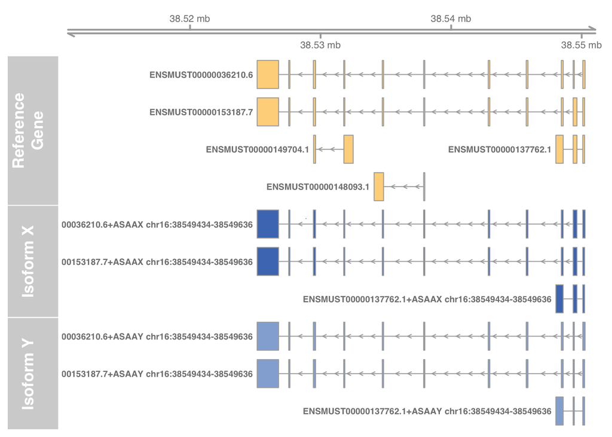

```r
geneModel.all <- GeneRegionTrack(makeGeneModel(gtf.exons[gtf.exons$gene_id == altTranscripts$gene_id[1]]),
                                 name="Reference Gene",
                                 showId=TRUE,transcriptAnnotation = "transcript")
# transcript X
geneModelX <- GeneRegionTrack(makeGeneModel(xTranscripts),
                                   name="Isoform X",
                                   showId=TRUE, fill="#4D7ABE",transcriptAnnotation = "transcript")
# transcript Y
geneModelY<- GeneRegionTrack(makeGeneModel(yTranscripts),
                                   name="Isoform Y",
                                   showId=TRUE, fill="#94AFD8",transcriptAnnotation = "transcript")

plotTracks(list(gtr,geneModel.all,geneModelX, geneModelY), extend.left = 1000, extend.right = 1000)
```

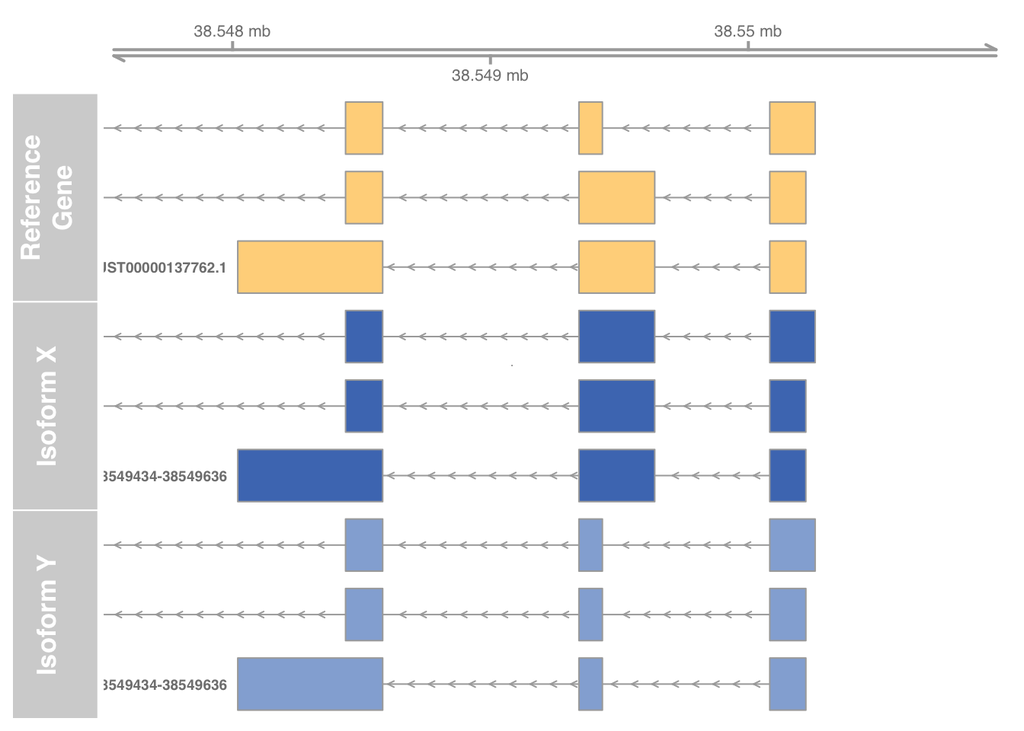

```r
# Zoomed in at the alternative acceptor site
plotTracks(list(gtr,geneModel.all,geneModelX, geneModelY), from = 38547500, to = 38551000)
```

#### Aternative donor

**1. Create normal and alternative isoform structures from whippet coordinates**

```r
# filter out alternative acceptor events (coded as "AD")
significant_events.ad <- significant_events[significant_events$type=="AD",]

# we will be looking at Mdbd3 (ENSMUSG00000035478.14)
significant_events.ad <- significant_events.ad[significant_events.ad$gene == "ENSMUSG00000035478.14",]

# whippet outputs the retained coordinates
ranges.ad <- whippet_coords[whippet_coords$id %in% significant_events.ad$coord]
# AD coordinates range from the normal donor splice site to the alternative donor splice site
ranges.ad
```

```
## GRanges object with 1 range and 1 metadata column:
##       seqnames               ranges strand |                      id
##          <Rle>            <IRanges>  <Rle> |             <character>
##   [1]    chr10 [80399122, 80399217]      - | chr10:80399122-80399217
##   -------
##   seqinfo: 21 sequences from an unspecified genome; no seqlengths
```

```r
# find exons pairs in the gtf that bound the retained intron event
junctionPairs <- findJunctionPairs(eventCoords = ranges.ad,
                                   jncCoords = jnc_ranges,
                                   type="AD")

# make transcripts with alternative junction usage
altTranscripts <- replaceJunction(junctionPairs = junctionPairs,
                                  eventCoords = ranges.ad,
                                  gtf.exons, type="AD")

# make transcripts using junction X
xTranscripts <- altTranscripts[altTranscripts$set=="AD_X"]
# make transcripts using junction Y
yTranscripts <- altTranscripts[altTranscripts$set=="AD_Y"]
```

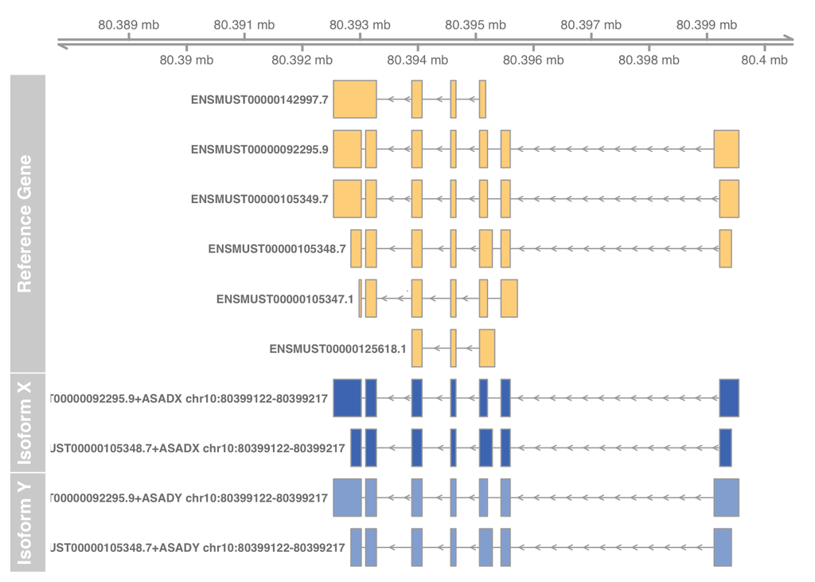

```r
geneModel.all <- GeneRegionTrack(makeGeneModel(gtf.exons[gtf.exons$gene_id == altTranscripts$gene_id[1]]),
                                 name="Reference Gene",
                                 showId=TRUE,transcriptAnnotation = "transcript")
# transcript X
geneModelX <- GeneRegionTrack(makeGeneModel(xTranscripts),
                                   name="Isoform X",
                                   showId=TRUE, fill="#4D7ABE",transcriptAnnotation = "transcript")
# transcript Y
geneModelY<- GeneRegionTrack(makeGeneModel(yTranscripts),
                                   name="Isoform Y",
                                   showId=TRUE, fill="#94AFD8",transcriptAnnotation = "transcript")

plotTracks(list(gtr,geneModel.all,geneModelX, geneModelY), extend.left = 1000, extend.right = 1000)
```

### Alternative first/last exons

Creation of alternative first/last isoforms currently relies on junction read counts supplied by whippet.

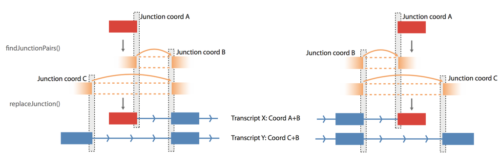

Creation of transcripts with an alternative first (left) or last (right) exon.

#### Alternative first exons

**1. Create normal and alternative isoform structures from whippet coordinates**

```r
# filter out alternative acceptor events (coded as "AF")
significant_events.af <- significant_events[significant_events$type=="AF",]

# we will be looking at Csrp1 (ENSMUSG00000029922.15)
significant_events.af <- significant_events.af[significant_events.af$gene == "ENSMUSG00000026421.14",]

# whippet outputs first (or last) exon being tested only
ranges.af <- whippet_coords[whippet_coords$id %in% significant_events.af$coord]
# AF/AL coordinates range are exon coordinates for the tested first/last exon
ranges.af
```

```
## GRanges object with 1 range and 1 metadata column:
##       seqnames                 ranges strand |                       id
##          <Rle>              <IRanges>  <Rle> |              <character>
##   [1]     chr1 [135729147, 135729274]      + | chr1:135729147-135729274
##   -------
##   seqinfo: 21 sequences from an unspecified genome; no seqlengths
```

```r
# find junction pairs that use the same acceptor/donor as the specified first/last exon
# i.e. find the alternative first/last exon
junctionPairs <- findJunctionPairs(eventCoords = ranges.af,
                                   jncCoords = jnc_ranges, type="AF")
```

You can create alternative isoforms manually by defining one of the first exons, and splice junctions which are used by this exon and an alternative first exon. See the schematic for details.

```r
ranges.af.manual <- GRanges(seqnames="chr1",
                            ranges=IRanges(start=135729147, # exon start
                                           end=135729274), # exon end
                            strand="+",
                            id="AF_manual")
junctionPairs.af.manual <- GRanges(seqnames="chr1",
                            ranges=IRanges(start=c(135729274, 135720193), # splice site 1 (first exon),  splice site 1 (alternative first exon)
                                           end=c(135739400,135739400)), #splice site 2 (shared junction pair)
                            strand=c("+","+"),
                            id=c("junction1", "junction2"),
                            whippet_id=rep("AF_manual", 2),
                            search=c("right", "right"), # search to the right for the shared junction pair
                            set=c("X","Y"))
```

```r
# make transcripts with alternative junction usage
altTranscripts <- replaceJunction(junctionPairs = junctionPairs,
                                  eventCoords = ranges.af,
                                  gtf.exons,
                                  type="AF")

# make transcripts using exon X
xTranscripts <- altTranscripts[altTranscripts$set=="AF_X"]
# make transcripts using exon Y
yTranscripts <- altTranscripts[altTranscripts$set=="AF_Y"]
```

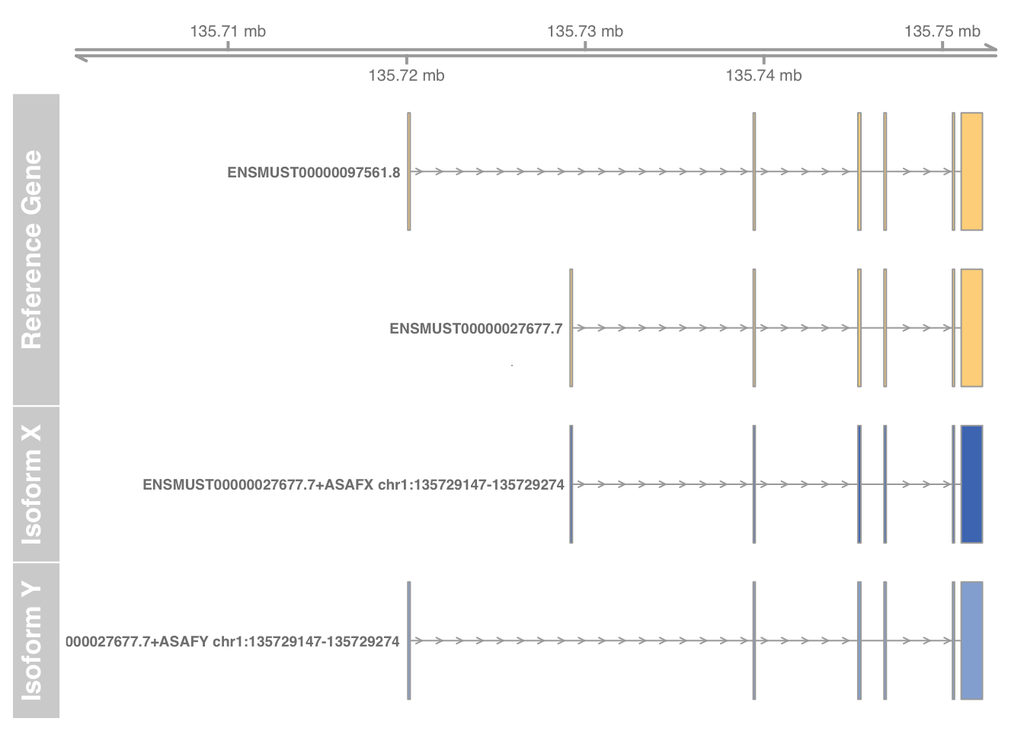

```r
geneModel.all <- GeneRegionTrack(makeGeneModel(gtf.exons[gtf.exons$gene_id == altTranscripts$gene_id[1]]),
                                 name="Reference Gene",
                                 showId=TRUE,transcriptAnnotation = "transcript")
# reference transcript
geneModelX <- GeneRegionTrack(makeGeneModel(xTranscripts),
                                   name="Isoform X",
                                   showId=TRUE, fill="#4D7ABE",transcriptAnnotation = "transcript")
# for the retained intron transcript
geneModelY<- GeneRegionTrack(makeGeneModel(yTranscripts),
                                   name="Isoform Y",
                                   showId=TRUE, fill="#94AFD8",transcriptAnnotation = "transcript")

# Only the transcript isoforms with exons at the boundries of the retained intron are used for analysis, and 'novel' isoforms are created by intron retention
plotTracks(list(gtr,geneModel.all,geneModelX, geneModelY), extend.left = 1000, extend.right = 1000)
```

#### Alternative last exons

**1. Create normal and alternative isoform structures from whippet coordinates**

```r
# filter out alternative acceptor events (coded as "AF")
significant_events.al <- significant_events[significant_events$type=="AL",]

# we will be looking at Ppm1b
significant_events.al <- significant_events.al[significant_events.al$gene == "ENSMUSG00000061130.12",]

# whippet outputs first (or last) exon being tested only
ranges.al <- whippet_coords[whippet_coords$id %in% significant_events.al$coord]
# AF/AL coordinates range are exon coordinates for the tested first/last exon
ranges.al
```

```
## GRanges object with 1 range and 1 metadata column:
##       seqnames               ranges strand |                      id
##          <Rle>            <IRanges>  <Rle> |             <character>
##   [1]    chr17 [85013566, 85014776]      + | chr17:85013566-85014776
##   -------
##   seqinfo: 21 sequences from an unspecified genome; no seqlengths
```

```r
# find junction pairs that use the same acceptor/donor as the specified first/last exon
# i.e. find the alternative first/last exon
junctionPairs <- findJunctionPairs(eventCoords = ranges.al,
                                   jncCoords = jnc_ranges, type="AL")

# make transcripts with alternative junction usage
altTranscripts <- replaceJunction(junctionPairs = junctionPairs,
                                  eventCoords = ranges.al,
                                  gtf.exons,
                                  type="AL")

# make transcripts using junction X
xTranscripts <- altTranscripts[altTranscripts$set=="AL_X"]
# make transcripts using junction Y
yTranscripts <- altTranscripts[altTranscripts$set=="AL_Y"]
```

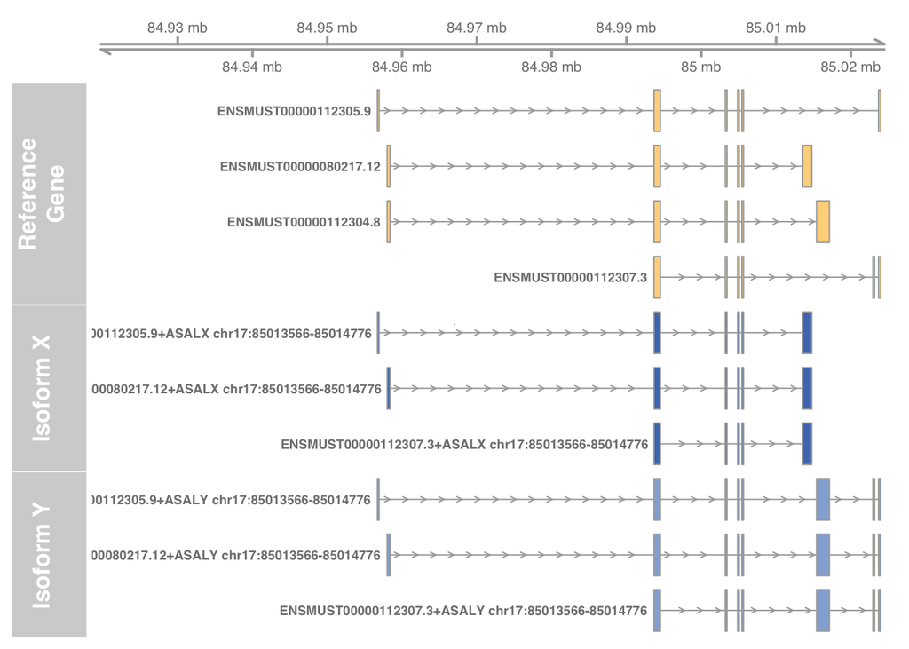

```r
geneModel.all <- GeneRegionTrack(makeGeneModel(gtf.exons[gtf.exons$gene_id == altTranscripts$gene_id[1]]),
                                 name="Reference Gene",
                                 showId=TRUE,transcriptAnnotation = "transcript")
# reference transcript
geneModelX <- GeneRegionTrack(makeGeneModel(xTranscripts),
                                   name="Isoform X",
                                   showId=TRUE, fill="#4D7ABE",transcriptAnnotation = "transcript")
# for the retained intron transcript
geneModelY<- GeneRegionTrack(makeGeneModel(yTranscripts),
                                   name="Isoform Y",
                                   showId=TRUE, fill="#94AFD8",transcriptAnnotation = "transcript")

# Only the transcript isoforms with exons at the boundries of the retained intron are used for analysis, and 'novel' isoforms are created by intron retention
plotTracks(list(gtr,geneModel.all,geneModelX, geneModelY), extend.left = 1000, extend.right = 1000)
```

## Annotate Open Reading Frames

**1. Find open reading frame features**

```r
significant_events.ce <- significant_events[significant_events$type=="CE",]

# we will be looking at Ndufv3 (ENSMUSG00000024038.16) again
significant_events.ce <- significant_events.ce[significant_events.ce$gene == "ENSMUSG00000024038.16",]
ranges.ce <- whippet_coords[whippet_coords$id %in% significant_events.ce$coord]
# find exons in the gtf that overlap the skipped exon event
exons.ce <- findExonContainingTranscripts(eventCoords = ranges.ce,
                                          gtf.exons = gtf.exons,
                                          gtf.transcripts = gtf.transcripts)
# make skipped and included exon transcripts
# removes the skipped exon from all transcripts which contain it
skippedExonTranscripts <- skipExonInTranscript(eventCoords = ranges.ce,
                                               skippedExons = exons.ce,
                                               gtf.exons,
                                               match="exact")
# make non-skipped exon transcripts
normalTranscripts <- gtf.exons[gtf.exons$transcript_id %in% exons.ce$transcript_id]

# get ORF details for each set of transcripts
orfs_normal <- getOrfs(normalTranscripts, BSgenome = g,
                       returnLongestOnly = FALSE, allFrames = TRUE)
orfs_skipped <- getOrfs(skippedExonTranscripts[skippedExonTranscripts$set == "skipped_exon"],
                        BSgenome = g,
                        returnLongestOnly = FALSE, allFrames = TRUE)
orfs_included <- getOrfs(skippedExonTranscripts[skippedExonTranscripts$set == "included_exon"],
                         BSgenome = g,
                        returnLongestOnly = FALSE, allFrames = TRUE)
head(orfs_normal[,-8])
```

```
##                      id               gene_id frame seq_length
## 1 ENSMUST00000046288.14 ENSMUSG00000024038.16     1        512
## 2 ENSMUST00000046288.14 ENSMUSG00000024038.16     2        512
## 3 ENSMUST00000046288.14 ENSMUSG00000024038.16     3        511
##   seq_length_nt start_site stop_site orf_length start_site_nt stop_site_nt
## 1          1537        428       466         38          1282         1399
## 2          1537        358       406         48          1073         1220
## 3          1537         19       487        468            57         1464
##   utr3_length min_dist_to_junction_a exon_a_from_start
## 1         139                     78                 2
## 2         318                    991                 1
## 3          74                    143                 2
##   min_dist_to_junction_b exon_b_from_final
## 1                    140                 0
## 2                    102                 1
## 3                     75                 0
```

```r
# id: transcript isoform id
# gene_id: gene id
# frame: which open reading frame (1:3)
# seq_length: sequence length (in AA)
# seq_length_nt: sequence length (in nt)
# start_site: ORF start site (in AA)
# stop_site: ORF stop site (in AA)
# orf_sequence: ORF sequence (not shown)
# orf_length: ORF length (in AA)
# start_site_nt:  ORF start site (in nt) / 5'UTR length
# stop_site_nt:  ORF stop site (in nt)
# utr3_length: 3'UTR length (in nt)
# min_dist_to_junction_a: distance from stop codon to upstream junction (junction A)
# exon_a_from_start: junction A exon number
# min_dist_to_junction_b: distance from stop codon to downstream junction (junction B),
# exon_b_from_final: junction B exon number (counting backwards from the final exon)
```

**2. Compare ORFs**

```r
# compare normal and skipped isoforms
orfChange <- orfDiff(orfsX = orfs_included,
                     orfsY = orfs_skipped,
                     filterNMD = FALSE,
                     compareBy="gene",
                     geneSimilarity = TRUE,
                     compareUTR=TRUE,
                     allORFs = orfs_normal)

orfChange
```

```
##                        id orf_length_bygroup_x orf_length_bygroup_y
## 1 chr17:31527310-31528401                  468                  104
##   utr3_length_bygroup_x utr3_length_bygroup_y utr5_length_bygroup_x
## 1                    74                    74                    57
##   utr5_length_bygroup_y filtered percent_orf_shared max_percent_orf_shared
## 1                    57    FALSE          0.2222222              0.2222222
##   orf_percent_kept_x orf_percent_kept_y gene_similarity_x
## 1          0.2222222                  1                 1
##   gene_similarity_y
## 1         0.2222222
```

```r
# id: splicing event ID
# orf_length_by_group_x: longest orf in first set of transcripts (included exon)
# orf_length_by_group_y: longest orf in second set of transcripts (skipped exon)
# utr3_length_by_group_x: 3'UTR length in first set of transcripts (included exon)
# utr3_length_by_group_y: 3'UTR length in second set of transcripts (skipped exon)
# utr5_length_by_group_x: 5'UTR length in first set of transcripts (included exon)
# utr5_length_by_group_y: 5'UTR length in second set of transcripts (skipped exon)
# filtered: filtered for NMD ?
# percent_orf_shared: percent of the ORF shared between skipped and included exon transcripts
# max_percent_orf_shared: theoretical maximum percent of the ORF that could be shared (orf_length_by_group_y / orf_length_by_group_x) or (orf_length_by_group_x / orf_length_by_group_y)
# orf_percent_kept_x: percent of the ORF in group x (included exon) contained in group y (skipped exon)
# orf_percent_kept_y: percent of the ORF in group y (skipped exon) contained in group x (included exon)
# gene_similarity_x: max percent of a normal ORF shared in the group x (included exon) transcript. If multiple ORF frames and transcripts are available, this is the maximum value from comparing the skipped isoform ORF to ALL normal isoform ORFs.
# gene_similarity_y: max percent of a normal ORF shared in the group y (skipped exon) transcript. If multiple ORF frames and transcripts are available, this is the maximum value from comparing the skipped isoform ORF to ALL normal isoform ORFs.
```

**2.b. Compare ORFs with NMD probability**

You can also use our package [“notNMD”](https://github.com/betsig/notNMD) to predict nonsense-mediated decay potential in transcripts

```r
# devtools::install_github("betsig/notNMD")
library(notNMD)
# we will be looking at Dnm2
significant_events.ce <- significant_events[significant_events$gene == "ENSMUSG00000024038.16" &
                                                   significant_events$type == "CE",]
# whippet outputs the skipped exon coordinates
ranges.ce <- whippet_coords[whippet_coords$id %in% significant_events.ce$coord]
# find exons in the gtf that overlap the skipped exon event
exons.ce <- findExonContainingTranscripts(ranges.ce, gtf.exons)


significant_events.ce <- significant_events[significant_events$type=="CE",]

# we will be looking at Ndufv3 (ENSMUSG00000024038.16) again
significant_events.ce <- significant_events.ce[significant_events.ce$gene == "ENSMUSG00000024038.16",]
ranges.ce <- whippet_coords[whippet_coords$id %in% significant_events.ce$coord]
# find exons in the gtf that overlap the skipped exon event
exons.ce <- findExonContainingTranscripts(eventCoords = ranges.ce,
                                          gtf.exons = gtf.exons,
                                          gtf.transcripts = gtf.transcripts)
# make skipped and included exon transcripts
# removes the skipped exon from all transcripts which contain it
skippedExonTranscripts <- skipExonInTranscript(eventCoords = ranges.ce,
                                               skippedExons = exons.ce,
                                               gtf.exons,
                                               match="exact")
# make non-skipped exon transcripts
normalTranscripts <- gtf.exons[gtf.exons$transcript_id %in% exons.ce$transcript_id]

# get ORF details for each set of transcripts
orfs_normal <- getOrfs(normalTranscripts, BSgenome = g,
                       returnLongestOnly = FALSE, allFrames = TRUE)
orfs_skipped <- getOrfs(skippedExonTranscripts[skippedExonTranscripts$set == "skipped_exon"],
                        BSgenome = g,
                        returnLongestOnly = FALSE, allFrames = TRUE)
orfs_included <- getOrfs(skippedExonTranscripts[skippedExonTranscripts$set == "included_exon"],
                         BSgenome = g,
                        returnLongestOnly = FALSE, allFrames = TRUE)

# calculate NMD probability
# --- note that if you have a different method for assessing NMD potential, you may substitute the values here
orfs_normal$nmd_prob <- notNMD::predictNMD(orfs_normal, "prob")
orfs_normal$nmd_class <- notNMD::predictNMD(orfs_normal)
orfs_skipped$nmd_prob <- notNMD::predictNMD(orfs_skipped, "prob")
orfs_skipped$nmd_class <- notNMD::predictNMD(orfs_skipped)
orfs_included$nmd_prob <- notNMD::predictNMD(orfs_included, "prob")
orfs_included$nmd_class <- notNMD::predictNMD(orfs_included)

orfs_normal <- orfs_normal[which(!is.na(orfs_normal$orf_length)),]
orfs_skipped <- orfs_skipped[which(!is.na(orfs_skipped$orf_length)),]
orfs_included <- orfs_included[which(!is.na(orfs_included$orf_length)),]


# compare normal and skipped isoforms
orfChange <- orfDiff(orfsX = orfs_included,
                     orfsY = orfs_skipped,
                     filterNMD = TRUE,
                     geneSimilarity = TRUE,
                     compareUTR=TRUE,
                     allORFs = orfs_normal)
nmdChange <- attrChangeAltSpliced(orfs_included,orfs_skipped,
                                           attribute="nmd_prob",
                                           compareBy="gene",
                                           useMax=FALSE)
m <- match(orfChange$id, nmdChange$id)
orfChange <- cbind(orfChange, nmdChange[m,-1])
orfChange
```

```
##                        id orf_length_bygroup_x orf_length_bygroup_y
## 1 chr17:31527310-31528401                  468                  104
##   utr3_length_bygroup_x utr3_length_bygroup_y utr5_length_bygroup_x
## 1                    74                    74                    57
##   utr5_length_bygroup_y filtered percent_orf_shared max_percent_orf_shared
## 1                    57     both          0.2222222              0.2222222
##   orf_percent_kept_x orf_percent_kept_y gene_similarity_x
## 1          0.2222222                  1                 1
##   gene_similarity_y nmd_prob_bygroup_x nmd_prob_bygroup_y
## 1         0.2222222         0.02708854         0.04398129
```

```r
# id: splicing event ID
# orf_length_by_group_x: longest orf in first set of transcripts (normalTranscripts)
# orf_length_by_group_y: longest orf in second set of transcripts (skippedExonTranscripts)
# utr3_length_by_group_x: 3'UTR length in first set of transcripts (normalTranscripts)
# utr3_length_by_group_y: 3'UTR length in second set of transcripts (skippedExonTranscripts)
# utr5_length_by_group_x: 5'UTR length in first set of transcripts (normalTranscripts)
# utr5_length_by_group_y: 5'UTR length in second set of transcripts (skippedExonTranscripts)
# filtered: filtered for NMD ?
# percent_orf_shared: percent of the ORF shared between skipped and included exon transcripts
# max_percent_orf_shared: theoretical maximum percent of the ORF that could be shared (orf_length_by_group_y / orf_length_by_group_x) or (orf_length_by_group_x / orf_length_by_group_y)
# orf_percent_kept_x: percent of the ORF in group x (included exon) contained in group y (skipped exon)
# orf_percent_kept_y: percent of the ORF in group y (skipped exon) contained in group x (included exon)
# gene_similarity_x: max percent of a normal ORF shared in the group x (included exon) transcript. If multiple ORF frames and transcripts are available, this is the maximum value from comparing the skipped isoform ORF to ALL normal isoform ORFs.
# gene_similarity_y: max percent of a normal ORF shared in the group y (skipped exon) transcript. If multiple ORF frames and transcripts are available, this is the maximum value from comparing the skipped isoform ORF to ALL normal isoform ORFs.
# nmd_prob_bygroup_x: mininmum NMD probability in first set of transcripts (normalTranscripts)
# nmd_prob_bygroup_y: mininmum NMD probability in second set of transcripts (skippedExonTranscripts)
```

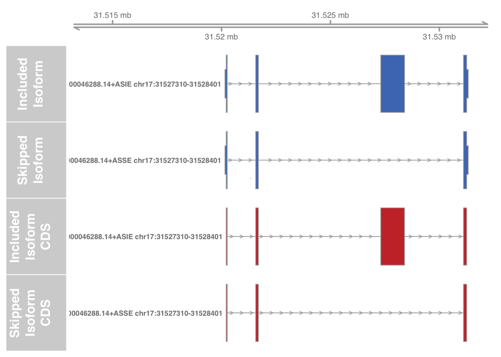

```r
# plot ORFs on transcripts
# annotate UTR/CDS locations
geneModel.skipped <- annotateGeneModel(skippedExonTranscripts[
    skippedExonTranscripts$set=="skipped_exon"], orfs_skipped)
geneModel.included <- annotateGeneModel(skippedExonTranscripts[
    skippedExonTranscripts$set=="included_exon"], orfs_included)

grtr.included <- GeneRegionTrack(geneModel.included,
                            name="Included Isoform",
                            showId=TRUE, fill="#4D7ABE",
                            transcriptAnnotation = "transcript")
# make tracks for non-nmd targeted CDS
grtrCDS.included <- GeneRegionTrack(geneModel.included[geneModel.included$feature == "CDS",],
                                name="Included Isoform CDS",
                                showId=TRUE,fill="#CB3634",
                                transcriptAnnotation = "transcript")

grtr.skipped <- GeneRegionTrack(geneModel.skipped,
                            name="Skipped Isoform",
                            showId=TRUE, fill="#4D7ABE",
                            transcriptAnnotation = "transcript")
# make tracks for non-nmd targeted CDS
grtrCDS.skipped <- GeneRegionTrack(geneModel.skipped[geneModel.skipped$feature == "CDS",],
                                name="Skipped Isoform CDS",
                                showId=TRUE,fill="#CB3634",
                                transcriptAnnotation = "transcript")
plotTracks(list(gtr, grtr.included, grtr.skipped, grtrCDS.included,grtrCDS.skipped), extend.left = 1000, extend.right = 1000)
```

```r
# Full length transcripts in blue, CDS only in red
```

By using GeneStructureTools and examining visually, we find that skipping of exon 3 in Ndufv3 decreases the size open reading frame (from 468 to 104AA), by removing an in frame exon - UTR lengths are unchanged and no alternative ORF sequence is generated.

```r
# we will be looking at Srsf1 (ENSMUSG00000018379.17) again
significant_events.ri <- significant_events[significant_events$gene == "ENSMUSG00000018379.17"
                                            & significant_events$type=="RI",]
# psi_a = 0.371, psi_b = 0.213
# percentage of transcripts retaining intron decreases from timepoint 1 to 21

# whippet outputs the retained coordinates
ranges.ri <- whippet_coords[whippet_coords$id %in% significant_events.ri$coord]
# need to extend whippet coords to cover the last/first base of the surrounding exons
start(ranges.ri) <- start(ranges.ri) -1
end(ranges.ri) <- end(ranges.ri) +1
# find exons pairs in the gtf that bound the retained intron event
exons.ri <- findIntronContainingTranscripts(ranges.ri, gtf.exons)
# make retained transcripts
# adds the intron into all transcripts which overlap it
retainedIntronTranscripts <- addIntronInTranscript(ranges.ri, exons.ri,
                                                         gtf.exons, glueExons = TRUE)
# make non-retained intron transcripts
normalTranscripts <- gtf.exons[gtf.exons$transcript_id %in% exons.ri$transcript_id]

# get ORF details for each set of transcripts
orfs_normal <- getOrfs(normalTranscripts, BSgenome = g,
                       returnLongestOnly = FALSE, allFrames = TRUE)
orfs_retained <- getOrfs(retainedIntronTranscripts[retainedIntronTranscripts$set == "retained_intron"],
                        BSgenome = g,
                        returnLongestOnly = FALSE, allFrames = TRUE)
orfs_spliced <- getOrfs(retainedIntronTranscripts[retainedIntronTranscripts$set == "spliced_intron"],
                         BSgenome = g,
                        returnLongestOnly = FALSE, allFrames = TRUE)

# compare normal and retained isoforms
orfChange <- orfDiff(orfsX = orfs_spliced,
                     orfsY = orfs_retained,
                     filterNMD = FALSE,
                     geneSimilarity = TRUE,
                     compareUTR=TRUE)

orfChange
```

```
##                        id orf_length_bygroup_x orf_length_bygroup_y
## 1 chr11:88049216-88049411                  253                  201
##   utr3_length_bygroup_x utr3_length_bygroup_y utr5_length_bygroup_x
## 1                   411                   763                    37
##   utr5_length_bygroup_y filtered percent_orf_shared max_percent_orf_shared
## 1                    37    FALSE                  0              0.7944664
##   orf_percent_kept_x orf_percent_kept_y
## 1                  0                  0
```

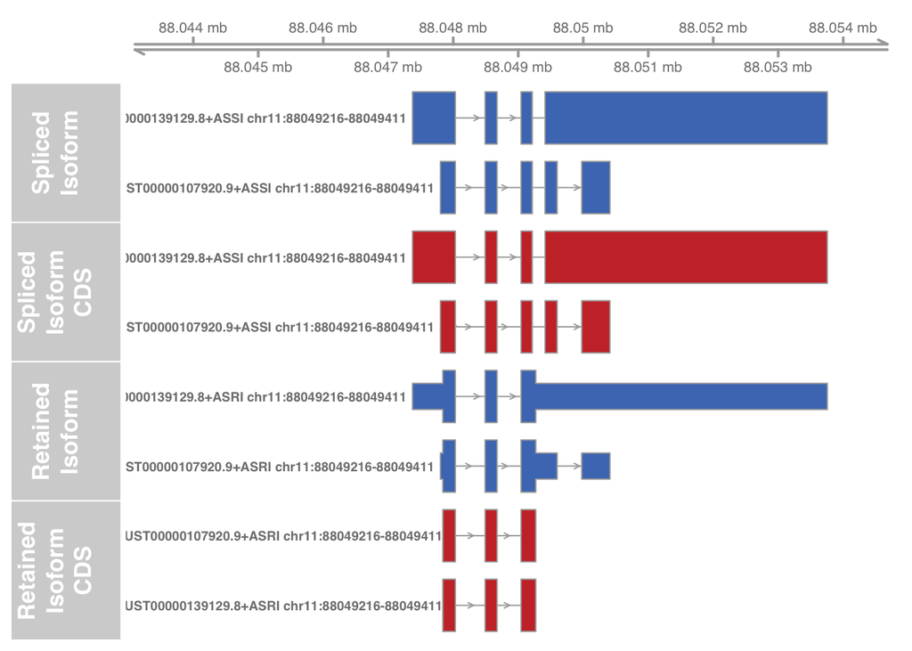

```r
# plot ORFs on transcripts

# annotate UTR/CDS locations
geneModel.retained <- annotateGeneModel(retainedIntronTranscripts[retainedIntronTranscripts$set == "retained_intron"], orfs_retained)
geneModel.spliced <- annotateGeneModel(retainedIntronTranscripts[retainedIntronTranscripts$set == "spliced_intron"], orfs_retained)


grtr.spliced <- GeneRegionTrack(geneModel.spliced,
                            name="Spliced Isoform",
                            showId=TRUE, fill="#4D7ABE",
                            transcriptAnnotation = "transcript")
grtrCDS.spliced <- GeneRegionTrack(geneModel.spliced[geneModel.spliced$feature == "CDS",],
                                name="Spliced Isoform CDS",
                                showId=TRUE,fill="#CB3634",
                                transcriptAnnotation = "transcript")

grtr.retained <- GeneRegionTrack(geneModel.retained,
                            name="Retained Isoform",
                            showId=TRUE, fill="#4D7ABE",
                            transcriptAnnotation = "transcript")
grtrCDS.retained <- GeneRegionTrack(geneModel.retained[geneModel.retained$feature == "CDS",],
                                name="Retained Isoform CDS",
                                showId=TRUE,fill="#CB3634",
                                transcriptAnnotation = "transcript")
gtr <- GenomeAxisTrack()
plotTracks(list(gtr, grtr.spliced, grtrCDS.spliced, grtr.retained, grtrCDS.retained), extend.left = 1000, extend.right = 1000)
```

```r
# Full length transcripts in blue, CDS only in red
```

By using GeneStructureTools and examining visually, we find that intron retention in Srsf1 decreases the size open reading frame (from 253 to 201AA), by generating a premature stop codon.

## DEXSeq

DEXSeq tests exons (or ‘exonic parts’) for differential usage between conditions. GeneStructureTools provides a few helper functions to help further annotate where in a transcript differential exon usage occurs.

### GTF reannotation

**Annotation of 5’ and 3’ UTRs**

Reannotates any blocks in a gtf GRanges that are annotated as a UTR and have a CDS block annotated in the same transcript.

```r
gtf <- rtracklayer::import("~/Downloads/gencode.vM14.annotation.gtf.gz")

table(gtf$type)
```

```
##
##           gene     transcript           exon            CDS    start_codon
##          51826         128622         769184         493367          55559
##     stop_codon            UTR Selenocysteine
##          51674         168835             65
```

```r
gtf_UTRannotated <- UTR2UTR53(gtf)
#some transfer from exon annotation to UTR3/5 due to overlapping with a reannotated UTR
table(gtf$type, gtf_UTRannotated$type)
```

```
##
##                     CDS   exon   gene Selenocysteine start_codon
##   gene                0      0  51826              0           0
##   transcript          0      0      0              0           0
##   exon                0 702933      0              0           0
##   CDS            493367      0      0              0           0
##   start_codon         0      0      0              0       55559
##   stop_codon          0      0      0              0           0
##   UTR                 0      0      0              0           0
##   Selenocysteine      0      0      0             65           0
##
##                  stop_codon transcript    UTR   UTR3   UTR5
##   gene                    0          0      0      0      0
##   transcript              0     128622      0      0      0
##   exon                    0          0      0  30246  36005
##   CDS                     0          0      0      0      0
##   start_codon             0          0      0      0      0
##   stop_codon          48230          0      0   3444      0
##   UTR                     0          0      5  81638  87192
##   Selenocysteine          0          0      0      0      0
```

**Annotation of broader transcript biotypes**

Reannotates transcript biotypes into lncRNA, nmd, protein coding, pseudogene, retained intron, and short ncRNA categories.

```r
gtf <- addBroadTypes(gtf)
table(gtf$transcript_type, gtf$transcript_type_broad)
```

```
##
##                                       lncRNA     nmd protein_coding
##   3prime_overlapping_ncRNA                10       0              0
##   antisense                            14930       0              0
##   bidirectional_promoter_lncRNA          715       0              0
##   IG_C_gene                                0       0              0
##   IG_C_pseudogene                          0       0              0
##   IG_D_gene                                0       0              0
##   IG_D_pseudogene                          0       0              0
##   IG_J_gene                                0       0              0
##   IG_LV_gene                               0       0              0
##   IG_pseudogene                            0       0              0
##   IG_V_gene                                0       0              0
##   IG_V_pseudogene                          0       0              0
##   lincRNA                              30775       0              0
##   macro_lncRNA                             9       0              0
##   miRNA                                    0       0              0
##   misc_RNA                                 0       0              0
##   Mt_rRNA                                  0       0              0
##   Mt_tRNA                                  0       0              0
##   non_stop_decay                           0     313              0
##   nonsense_mediated_decay                  0  142846              0
##   polymorphic_pseudogene                   0       0              0
##   processed_pseudogene                     0       0              0
##   processed_transcript                 78867       0              0
##   protein_coding                           0       0        1243574
##   pseudogene                               0       0              0
##   retained_intron                          0       0              0
##   ribozyme                                 0       0              0
##   rRNA                                     0       0              0
##   scaRNA                                   0       0              0
##   scRNA                                    0       0              0
##   sense_intronic                         878       0              0
##   sense_overlapping                      215       0              0
##   snoRNA                                   0       0              0
##   snRNA                                    0       0              0
##   sRNA                                     0       0              0
##   TEC                                      0       0              0
##   TR_C_gene                                0       0              0
##   TR_D_gene                                0       0              0
```

[output cut: 95 more lines]

```
##   snRNA                                     2766
##   sRNA                                         4
##   TEC                                       6179
##   TR_C_gene                                   98
##   TR_D_gene                                   12
##   TR_J_gene                                  210
##   TR_J_pseudogene                             20
##   TR_V_gene                                 1206
##   TR_V_pseudogene                             81
##   transcribed_processed_pseudogene             0
##   transcribed_unitary_pseudogene               0
##   transcribed_unprocessed_pseudogene           0
##   translated_processed_pseudogene              0
##   unitary_pseudogene                           0
##   unprocessed_pseudogene                       0
```

### DEXSeq event overlapping

```r
# load dexseq processed data
load("~/Downloads/GeneStructureTools_VignetteFiles/dexseq_processed.Rdata")
# import dexseq gtf
dexseq_ranges <- rtracklayer::import("~/Downloads/GeneStructureTools_VignetteFiles/gencode.vM14.annotation.dexseq.gtf")

dexseq_results <- as.data.frame(dxr1)
# 3395 events significant
dexseq_results.significant <- dexseq_results[which(dexseq_results$padj < 0.01),]

# find the exon type of the significant events
dexseq_results.significant$overlap_types <- findDEXexonType(rownames(dexseq_results.significant), dexseq_ranges, gtf=gtf_UTRannotated)
overlap_types <- table(dexseq_results.significant$overlap_types)

# broader definition
dexseq_results.significant$overlap_types_broad <- summariseExonTypes(dexseq_results.significant$overlap_types)
table(dexseq_results.significant$overlap_types_broad)
```

```
##
##            CDS noncoding_exon    start_codon     stop_codon           UTR3
##           1078            464            294            553            737
##           UTR5
##            269
```

```r
### Gene enrichment in exon events
library(clusterProfiler)
# backgroud of highly expressed genes/exons
background_exons <- rownames(dexseq_results)[dexseq_results$exonBaseMean >= min(dexseq_results.significant$exonBaseMean)]

#convert DEXseq ids to gene ids for clusterprofiler
background_genes <- DEXSeqIdsToGeneIds(background_exons, removeVersion = TRUE)
background <- bitr(background_genes, fromType="ENSEMBL", toType = c("ENTREZID","SYMBOL"), OrgDb = "org.Mm.eg.db")
# all genes
significant_genes <- DEXSeqIdsToGeneIds(dexseq_results.significant$groupID, removeVersion = TRUE)
genes <- bitr(significant_genes, fromType="ENSEMBL", toType = c("ENTREZID","SYMBOL"), OrgDb = "org.Mm.eg.db")
go <- enrichGO(genes$ENTREZID, OrgDb = "org.Mm.eg.db", ont="BP", readable=TRUE, universe=background$ENTREZID)

# CDS / start codon / stop codon only
significant_genes <- DEXSeqIdsToGeneIds(dexseq_results.significant$groupID[dexseq_results.significant$overlap_types_broad %in% c("CDS","start_codon","stop_codon")], removeVersion = TRUE)
genes <- bitr(significant_genes, fromType="ENSEMBL", toType = c("ENTREZID","SYMBOL"), OrgDb = "org.Mm.eg.db")
go_cds_group <- enrichGO(genes$ENTREZID, OrgDb = "org.Mm.eg.db", ont="BP", readable=TRUE, universe=background$ENTREZID)

# noncoding exons only
significant_genes <- DEXSeqIdsToGeneIds(dexseq_results.significant$groupID[dexseq_results.significant$overlap_types_broad == "noncoding_exon"], removeVersion = TRUE)
genes <- bitr(significant_genes, fromType="ENSEMBL", toType = c("ENTREZID","SYMBOL"), OrgDb = "org.Mm.eg.db")
go_noncoding <- enrichGO(genes$ENTREZID, OrgDb = "org.Mm.eg.db", ont="BP", readable=TRUE, universe=background$ENTREZID)

table(dexseq_results.significant$overlap_types_broad)
```

```
##
##            CDS noncoding_exon    start_codon     stop_codon           UTR3
##           1078            464            294            553            737
##           UTR5
##            269
```

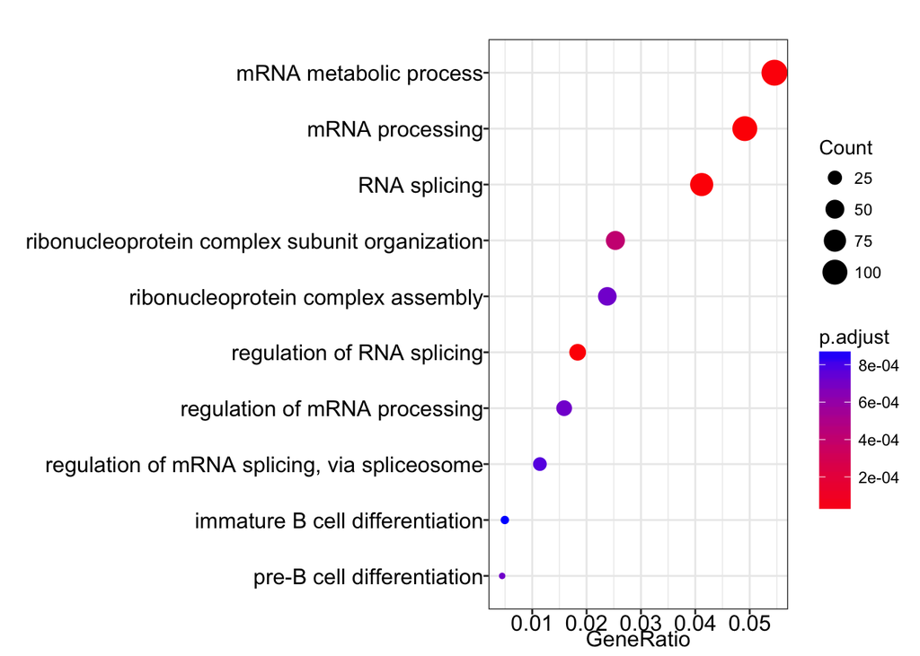

```r
# enriched overall
dotplot(go, showCategory=10)
```

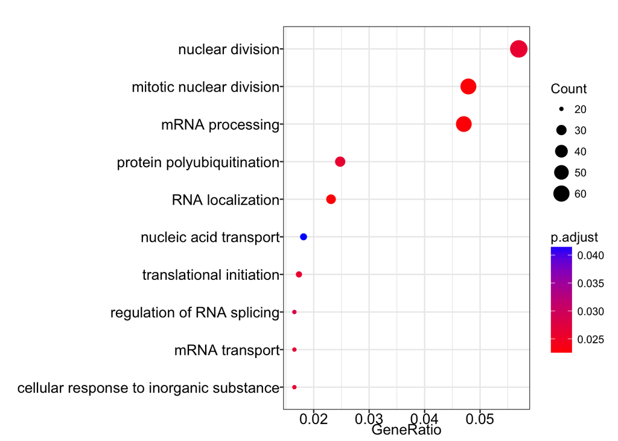

```r
# enriched at CDS
dotplot(go_cds_group, showCategory=10)
```

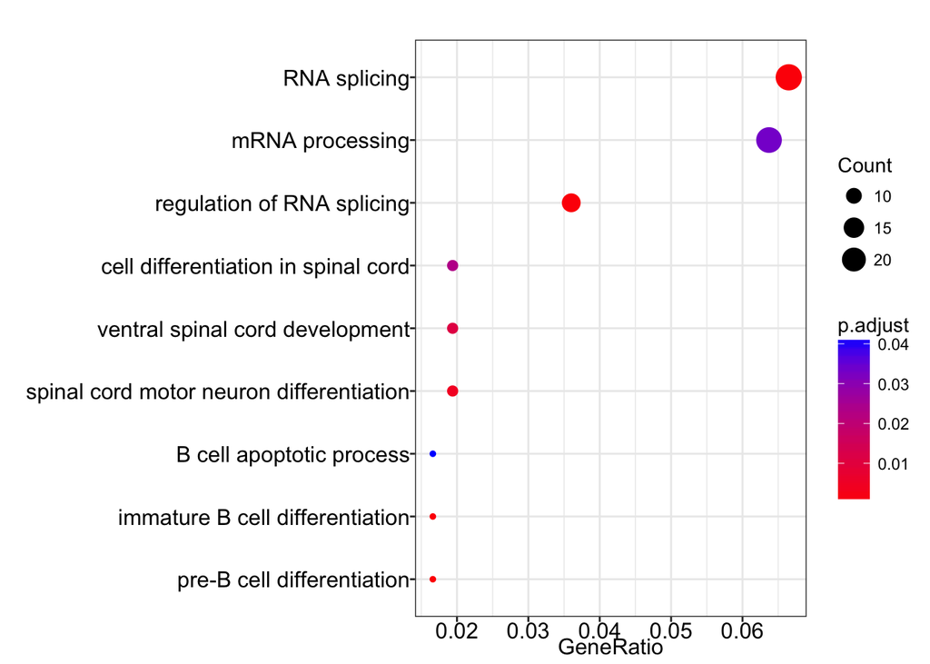

```r
# enriched in noncoding exons
dotplot(go_noncoding, showCategory=10)
```